# Assignment 4

Shawn Schneideriet

25.11.2020

## **note** that the .Rmd can be found on my [personal repo](https://github.com/schneidereits/Quantitative_Methods_HU/tree/main/assignments) for the corse

### Steps to complete your assignment:

1. Complete the tasks. Write your R code in the designated areas (you can send the code to the console to test your code).
2. Create an HTML file in R-Studio: | Menu | File | Knit Document (alternatively: little Knit button in script header)
3. RENAME your html file to “Assignment_Lab04_YourLastName.html” (replace your last name)
4. Upload your assignment (.html file) to Moodle

### 1. Build a hypothesis for the airquality data (1 points)

Suppose you are tasked to analyze how the variability in near-surface ozone concentrations in New York is associated with local variations in weather conditions. With the airquality data set, plot ozone concentration (ppb) versus temperature (degrees F). Based on the observed relationship, phrase a plausible (!) research hypothesis. Think about which variable to plot on the x- and y-axes.

```r
airquality <- read_csv("~/Documents/humbolt/quantitative_methods/pc_lab/data/airquality_output.csv")
```

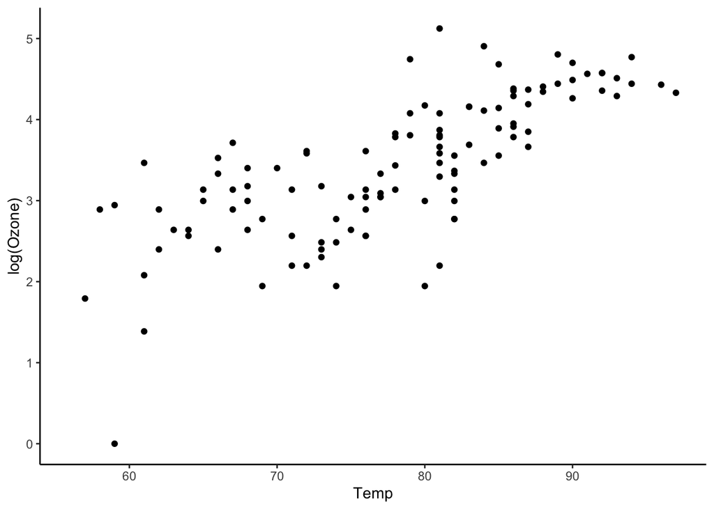

```r
ggplot(airquality, aes(Temp, log(Ozone))) +
  geom_point() +
  theme_classic()
```

```r
# Near-surface will significantly affect observed ozone concentration, with progressive increases in temperature corresponding with higher ozone concentration
```

### 2. Fit a linear model to the airquality data (3 points)

Fit a simple linear regression model using ordinary-least-squares regression between ozone concentration and temperature to analyze the effect of temperature on ozone. Briefly answer the following questions: (1) How does ozone concentration change with Temperature? (2) Is the effect of temperature on ozone concentration significant? (3) How much of the variance in ozone concentration is explained by temperature alone? Show how you obtained the results with R?

```r
m1 <- lm(data = airquality, Ozone ~ Temp)

summary(m1)
```

```
##
## Call:
## lm(formula = Ozone ~ Temp, data = airquality)
##
## Residuals:
##     Min      1Q  Median      3Q     Max
## -40.729 -17.409  -0.587  11.306 118.271
##
## Coefficients:
##              Estimate Std. Error t value Pr(>|t|)
## (Intercept) -146.9955    18.2872  -8.038 9.37e-13 ***
## Temp           2.4287     0.2331  10.418  < 2e-16 ***
## ---
## Signif. codes:  0 '***' 0.001 '**' 0.01 '*' 0.05 '.' 0.1 ' ' 1
##
## Residual standard error: 23.71 on 114 degrees of freedom
##   (37 observations deleted due to missingness)
## Multiple R-squared:  0.4877, Adjusted R-squared:  0.4832
## F-statistic: 108.5 on 1 and 114 DF,  p-value: < 2.2e-16
```

```r
# 1) Temperature has a positve effect on ozone conentration, with a 1 degree F increase in temp resulting in a 2.43 ppb increase in ozone
# 2) Yes the observed effect of tempurature on ozone is observed to be significant as p< 0.05 and the std. error is being relatively small when compaired to the slope (effect size)
# 3) ~48 percent of the total variance is explained by tempurature alone. This is observed in the adjusted R-squared value found in the summary table
```

### 3. Plot the regression (2 Points)

Create a plot showing the fitted relationship between temperature and ozone concentration. Also show uncertainties in the regression line caused by uncertainty in the parameter estimates (confidence interval).

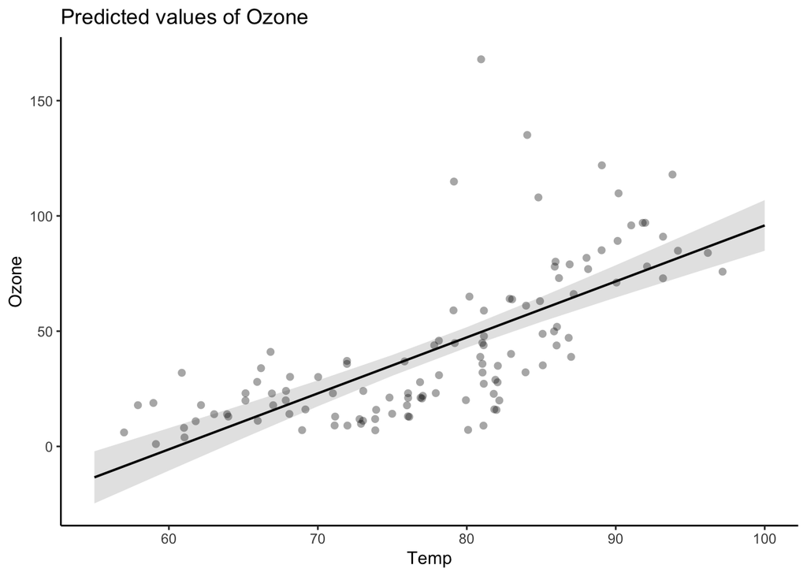

```r
ggpredict(m1, terms = c("Temp"), type = "fe", ci.lvl = 0.95) %>%  # type = fe(fixed effect) because model is non-hirearcical
  plot(rawdata = TRUE) +
  theme_classic()
```

### 4. Model diagnostics (3 Points)

Create two residual plots for the model: 1) a qq-plot and 2) a scatter-plot of fitted values versus residuals. Do the residuals look normal and properly distributed? Answer the question in 2-3 sentences.

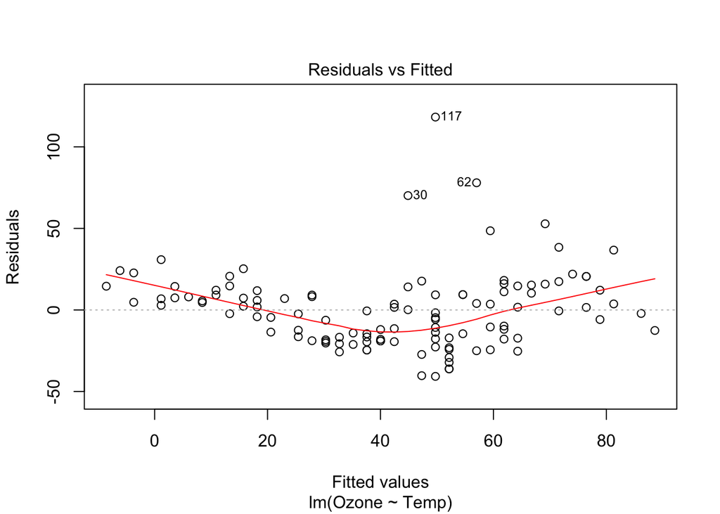

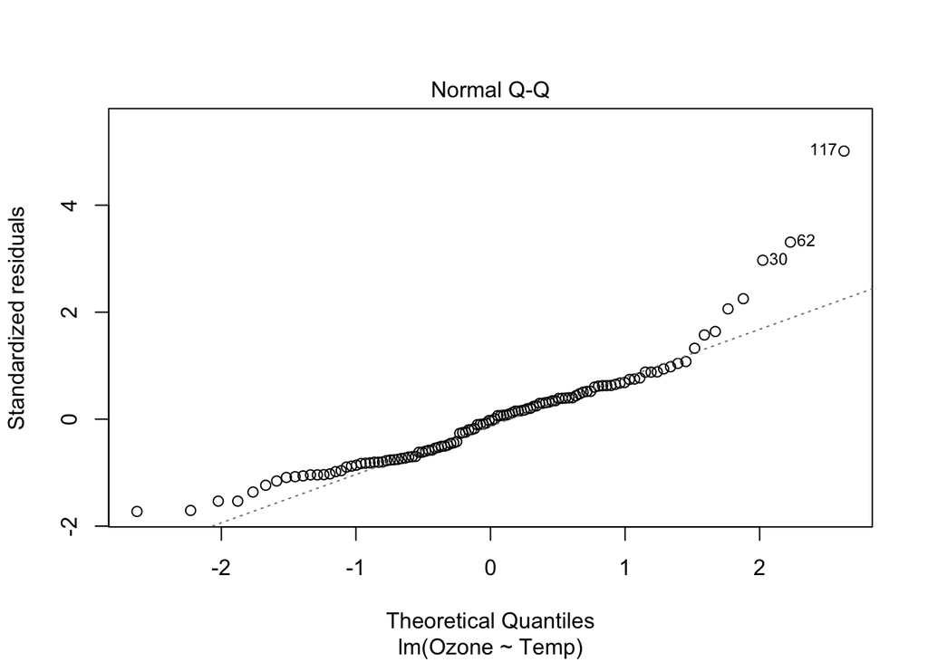

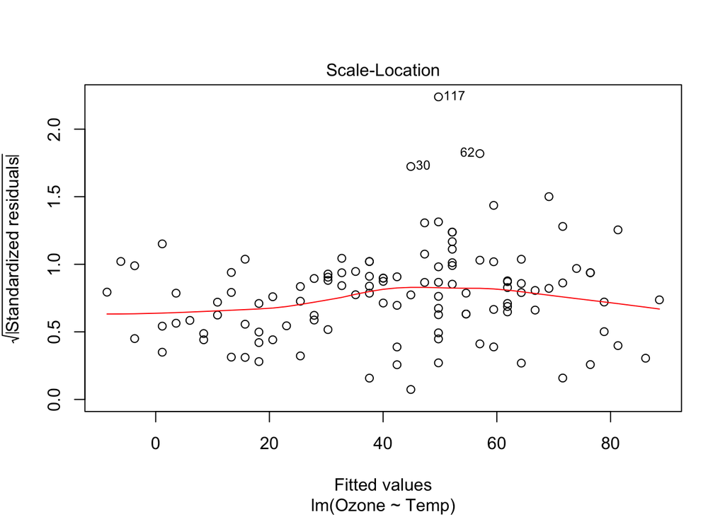

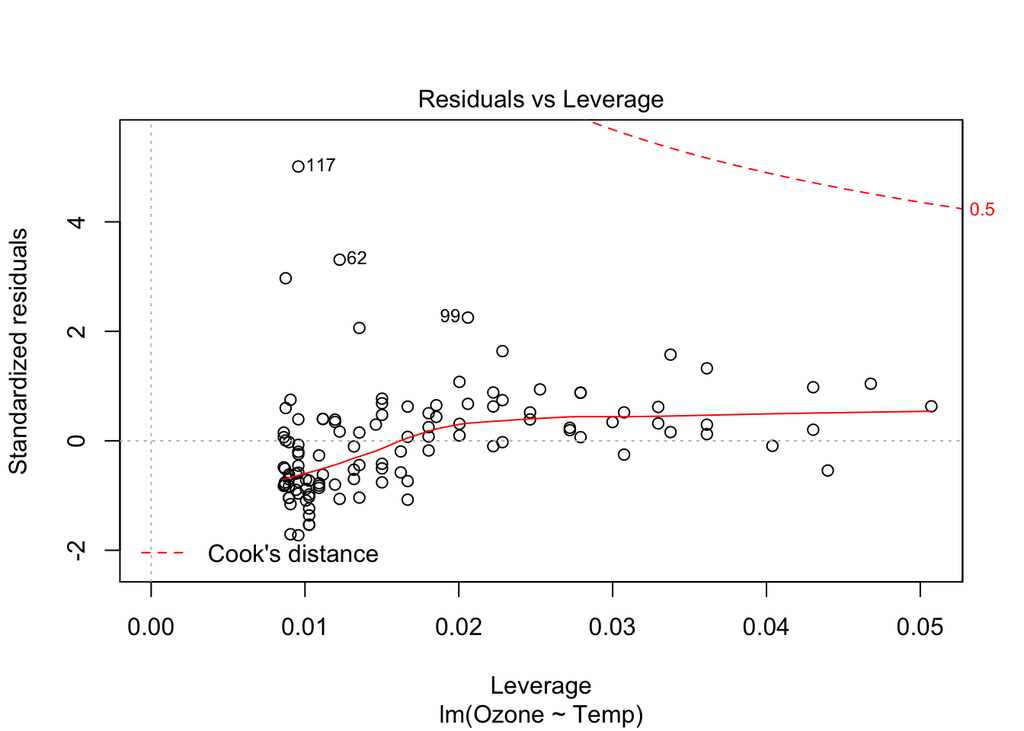

```r
plot(m1) # bottom row can be ignored
```

```r
 # The data have slight irregularities that do not make it look normal and properley distributed. while the in residual vs fitted plot the data points mostly appear to be spread out about the line, there is a discernible trend in the middle section of the line, with a slight downward deviation. The Q-Q plot shows that the data has a heaver upper tale and that data points with larger values have a positve deviation from what is to be expected under the standard modelling assumption.
```

### 5. Transforming the response (3 Points in total, each part 1 point)

5.1 Create a new column ‘logOzone’ in the airquality dataset by calculating the natural logarithm of Ozone concentration. Following, fit a model explaining the logarithm of ozone concentration by temperature.

```r
airquality <- airquality %>%
  mutate(logOzone = log(Ozone))

m2 <- lm(data = airquality, logOzone ~ Temp)

summary(m2)
```

```
##
## Call:
## lm(formula = logOzone ~ Temp, data = airquality)
##
## Residuals:
##      Min       1Q   Median       3Q      Max
## -2.14469 -0.33095  0.02961  0.36507  1.49421
##
## Coefficients:
##             Estimate Std. Error t value Pr(>|t|)
## (Intercept) -1.83797    0.45100  -4.075 8.53e-05 ***
## Temp         0.06750    0.00575  11.741  < 2e-16 ***
## ---
## Signif. codes:  0 '***' 0.001 '**' 0.01 '*' 0.05 '.' 0.1 ' ' 1
##
## Residual standard error: 0.5848 on 114 degrees of freedom
##   (37 observations deleted due to missingness)
## Multiple R-squared:  0.5473, Adjusted R-squared:  0.5434
## F-statistic: 137.8 on 1 and 114 DF,  p-value: < 2.2e-16
```

5.2 Check the residuals of the model. Do they look different/better/worse than for the previous model?

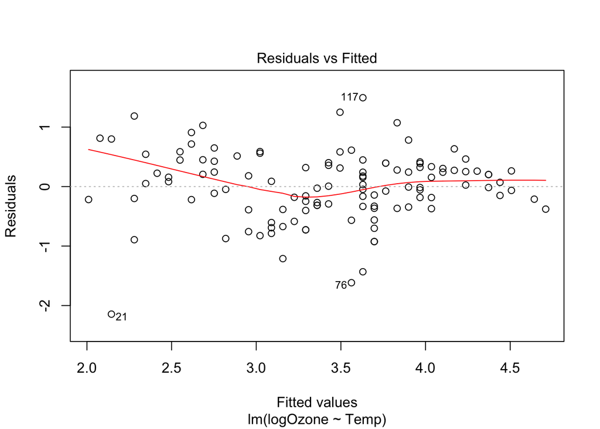

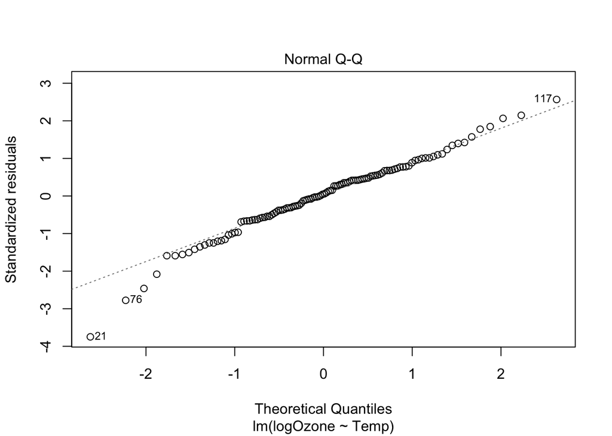

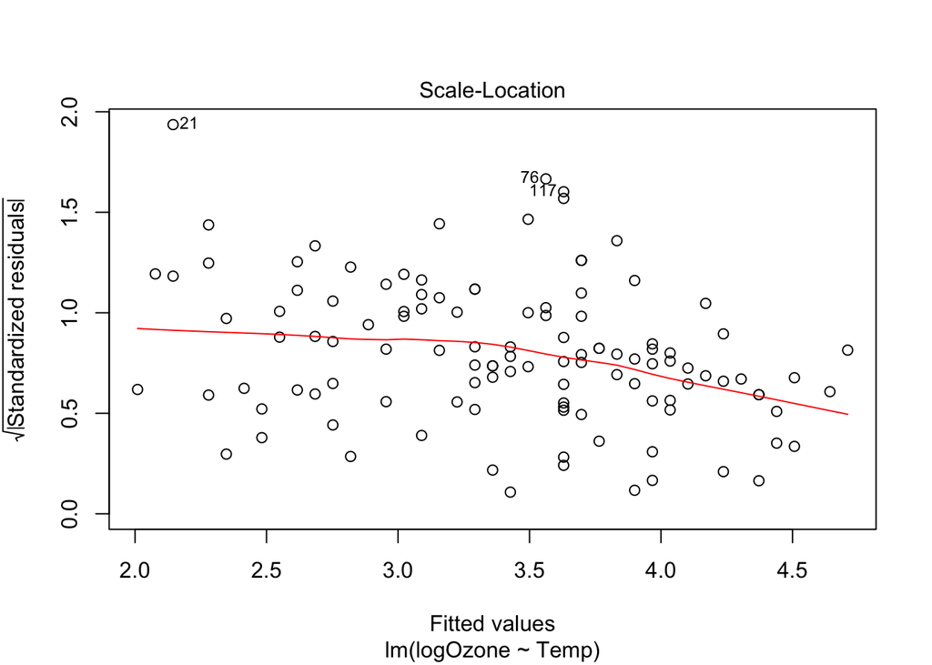

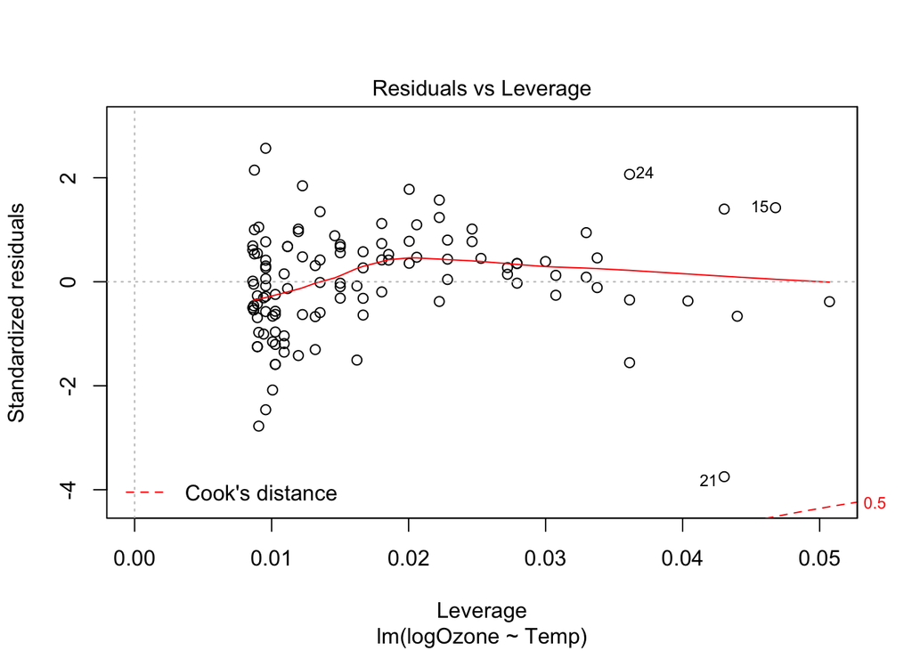

```r
plot(m2)
```